# Synchronized Neural Networks

By Jacob Tiede

# Introduction:

## Overview:

In this paper I will evaluate current research into how neural networks can become synchronized. Specifically, I will review the paper “Synchronization in Networks of Excitatory and Inhibitory Neurons with Sparse, Random Connectivity” by Christoph Borgers and Nancy Kopell [1]. Broadly speaking, they detail how network parameters affect the approximate synchronized behavior of a neural network that is sparsely connected. I plan on using the model detailed in [1] to create a network that can approximate circadian rhythm in humans as detailed in “Human sleep and circadian rhythms: a simple model based on two coupled oscillators” by S Strogatz [2]. This paper proposes a model for circadian rhythm based off of two coupled oscillators: one keeping track of the sleep cycle itself, and the other based off of body temperature. I would then like to construct a neural network that will be desynchronized during sleep and synchronized otherwise. To accomplish this some of the parameters in the neural network will be based off of a cosine wave with a certain frequency. After this I will extend this idea to two neural networks that are each connected and each with different frequencies. Using this model we will show that variance in sleep cycles is only possible when another network that is not influenced by temperature is considered. We will find that this two network model is sufficient to explain effects like jet lag, but it does not explain effects of internal desynchronization (detailed in [2], this is when someone is deprived of external circadian stimulus).

## A Summary of [1]:

The motivation, at least to my mind, for studying synchronized neural networks is because each neuron in a network might not have a large effect on the displayed behavior, so multiple neurons must work in tandem for behaviors to occur. One way to explain this would be changes in the synchronized state of a neural network responsible for a given activity, for instance, moving your arm. If all the neurons involved with the complex movement of an arm are synchronized then we would expect the arm to move, whereas if they were all behaving separately might only cause fasciculations. [1] seeks to better understand when neural networks are working in tandem, and how these synchronized behaviors come about.

This paper concerns itself with networks built from two types of neurons: excitatory (E-cells), and inhibitory (I-cells). This is because prior work in the field indicated that networks under ideal conditions could often become synchronized due to the interactions between these two cell types [1]. For the purposes of [1] a model is considered ‘ideal’ if the neural network has all-to-all connectivity (every neuron is connected to every other neuron), as well as complete homogeneity of all relevant network parameters. These types of networks have been shown to perfectly synchronize via a mechanism called pyramidal interneuronal network gamma (PING). We will leave the specific conditions under which PING will cause synchronized firing for later in the paper, but suffice to say the ideal network can be made to meet all of them. Non-ideal networks cannot necessarily achieve perfect synchronized behavior, but they can achieve an approximation where a volley of spikes is fired from a population of neurons for some duration, followed by a pause in firing before another volley fires. The primary concern of [1] is to find how the duration of these volleys depends on network parameters, as well as how the shape (as in histogram or probability distribution) of the volleys is affected by network parameters in the context of the PING mechanism for synchronization. To do this they construct a non-ideal network by connecting neurons sparsely and randomly.

The authors begin by detailing the model’s neurons, and how they function. These are so called “Theta Neurons” which are meant to model the four-dimensional limit cycle from the Hodgkin-Huxley (H&H) model in two dimensional space. This model considers neurons as a point that lives on a unit circle (this circle represents the analog of the four dimensional limit cycle predicted by H&H’s model). The synapses between these neurons will take into account synaptic strength, synaptic gating variables, and which population the presynaptic neuron belonged to. These will then be used to construct a neural network with sparse connections for the purpose of simulating and confirming results from later in the paper.

Initially, they found that close to ideal synchronization is possible even for very sparse networks if there is no variance in the number of inputs for each neuron in a cell population. In fact, the authors found through simulation that there is a certain number of excitatory inputs per I-cell required to create synchronization, but this number is very low (in the case where there is no variance in the inputs to cell populations). What is interesting about this result is that most cells in a real brain receive many more inputs than the minimum required to form this tight synchronization in this case. This suggests that the variance in the number of inputs per cell in a population is what influences synchronized behavior in neurons rather than the number of inputs [1].

Motivated by this, the authors of [1] begin to look at how the components of the PING mechanism work in sparse randomly connected networks. In general, if 4 conditions are met (discussed later) PING will cause synchronization because of the following sequence of events. Random activity in the E-cells will cause a spike in activity in the I-cells (this can be thought of as a pulse of non-uniform strength received by the E-cells). This inhibition will force the E-cells to stop spiking, which will stop the I-cells from receiving any input. After a delay (where most excitatory neurons will be unable to fire due to I-cells firing) the I-cells lose the ability to fire because the stimulation that drove them to fire (activity of the E-cells) is now gone. This will cause a period where both cell populations are not firing very much (since the E-cells are still inhibited, and the I-cells are no longer receiving input) before the E-cells begin the fire again. Intuitively, the E-cells should be firing closer together in time after this pause since the inhibition should wear off at approximately the same time for most cells in the population. After this time a non-uniform pulse will be emitted by the E-cells into the I-cells causing the I-cell population to become more synchronized as well.

Clearly I am glossing over some details since not every non-uniform pulse will cause synchronized behavior. In fact, the authors of [1] show that this non-uniform pulse must have a large enough mean effect on the other cell population (ie if each cell in the I-cell population receives a random stimulation from the E-cells the mean stimulation must be sufficiently high), and the variance of this pulse's effect must be sufficiently low in order for the PING mechanism to work. Specifically, they find that the duration of a spike volley preceded by an inhibitory pulse is approximately $\tau_I\frac{\sigma_g}{\bar{g}}$ where $\tau_I$ is the time constant of the effect of the inhibitory neurons, $\sigma_g$ is the standard deviation of the input to the neuron, and $\bar{g}$ is the mean of the input strength. Interestingly, there is not exact symmetry between the spike volley duration preceded by an inhibitory pulse and those preceded by an excitatory pulse, in fact the equation for the duration of the spike volley preceded by an excitatory pulse is $\frac{\pi\sigma_g}{4\bar{g}^{3/2}}$ so the dependence on the time constant is lost in the case of an excitatory pulse. We can reasonably interpret g as the number of inputs to a particular cell (as a random normally distributed variable), so these equations give us a way to determine how connected a network needs to be to attain approximate synchronized behavior.

The authors also derive the shape of this approximate synchronized behavior, which they verified through simulation. We will reproduce these results in the results section. Since I won't be using this result for the extension of the paper I will allow the later sections to go into more detail.

## Summary of Project Extension

For my extension I posit that sleep is a function of many different processes, but is primarily related to body temperature (see [2]). In [3] it was found that AMPA receptors change with temperature, specifically at high temperature AMPA channels increase their conductance, and at low temperature they decrease their conductance. We will use this as an analog of synaptic conductance for out-going signals from E-cells. We will think of a sparsely connected network involved with sleep. There are many brain processes involved with sleep (motor neurons to make eye lids droop, higher level neurons to make someone tired, etc), so we can think of our network as all of the neurons involved with the process of being sleep (taken from many different parts of the brain). Since each of these neurons are most likely involved in many different mental processes we will need a way to interpret the signals from this network as sleep signals or non-sleep signals. In our case we will say that 'non-sleep' signals will be when the network is synchronized and sleep signals will be when the network is desynchronized. We will show later (using the analysis from [1]) that, because we are only varying the outgoing E-cell signals we will still attain synchronized behavior of the E-cells, however they will be able to fire much faster than when they are 'desynchronized'. Therefore, we can assume that the networks we create work to stimulate some kind of sleep response (so that more rapid 'desynchronized' behavior predicts sleep, and less rapid 'synchronized behavior predicts wakefulness).

[2] details that under normal circumstances sleep begins toward body temperature minima and waking occurs when body temperature begins to increase. This will be the basis for our construction of a single temperature dependent neural network (we will get rapid firing at temperature lows and slow firing at temperature highs). This will work, but because body temperature is consistent in its fluctuations for the most part [2] we will need another network to observe variance in sleep episodes. We show that creating another neural network with a different frequency can be made to shorten, lengthen, or eliminate sleep episodes entirely. This second neural network could be thought to incorporate external circadian stimulus, so this could be used to account for effects like jet lag on sleep.

[2] also details a process called internal desynchronization. This occurs when a person is deprived of changing external circadian related stimuli (like changes in light as the day progresses). This causes elongated periods of sleep, as well as shortened periods of sleep (with the possibility of completely missing a period where the subject would normally sleep). The authors of [2] state that longer sleep cycles are predicted when body temperature reaches a maximum in desynchronized patients have longer sleep episodes (if they do fall asleep). In the model we have proposed this is not possible since even if sleep occurred at a temperature max (by making the conductance of the outgoing E-cell connections in the temperature dependent neural network small) then it would still be a shorter sleep episode than those that occur at a temperature trough. We propose a possible fix for this as allowing the max conductance (or more accurately the amplitude of the oscillations in E-cell synaptic conductivity) of the neural network for temperature dependent neural network to vary in time, but more work in this area is required to accurately reproduce results associated with internal desynchronization, as there could be different more physiologically relevant solutions to this problem.

# Methods:

## The Single Neuron Model From [1]:

In [1] they detail a single neuron in their network as an approximation to the four dimensional limit cycle predicted by the H&H model. The equation for this two dimensional representation can be written as: $$ \frac{d\theta}{dt}=\frac{1}{\tau}(1-cos(\theta))+I(1+cos(\theta)) $$ If one thinks of this as a two dimensional limit cycle that lives along a unit circle then $\theta$ represents where we are on the unit cycle (the angle created by drawing a line from 0 to 1 on the x-axis, and the line drawn from the origin to the point of the circle that we are currently at). $I$ is the input current, and $\tau$ can be thought of as the membrane time constant. The main feature in this equation that the authors of [1] are interested in is when spiking occurs. To detail this the paper considers the bifurcation of the equation as $I$ goes from negative to positive values. The authors state that for $I<0$ there are two fixed points, when $I=0$ these two fixed points come together at $\theta = 0$ as a saddle node, and for $I>0$ there is no fixed point. The important thing to note about this behavior is that for $0<I<<1/\tau$ the saddle node's effect can still be seen in the model as the model will slow down around $\theta = 0$ and speed up for the rest of the model. A quick proof of this is as follows:
$$ \begin{align} \frac{d\theta}{dt}&=\frac{1}{\tau}(1-cos(\theta))+I(1+cos(\theta))\\ &=\frac{1}{\tau}+I+cos(\theta)(I-\frac{1}{\tau}) \end{align} $$ One can see that because both $I$ and $\tau$ are greater than zero, then $\frac{1}{\tau}+I > 0$. If we think of $\theta$ as close to zero we would expect $cos(\theta) \approx .99$ so our end expression is: $$ \frac{1}{\tau}-.99\frac{1}{\tau}+2I $$ Which will indeed be close to zero if $I<<\frac{1}{\tau}$.

This slow part can be thought of as the neuron building back up to a spike, and the fast part can be thought of as the spike itself. This intuition is used by the authors to say that as $\theta$ moves across $(2l-1)\pi$ (where l is an integer) the neuron spikes (note: this is because when $\theta$ is an odd integer we are the furthest that we can be from the $\theta = 0$, so we should be moving the fastest that the model will move, which is indicative of a spike). The paper also notes that $sin(\theta)$ can be thought of as the voltage of the neuron, so we can quickly visualize these spikes in python:

```
Spike times:
[11.11, 33.324, 55.538000000000004, 77.753, 99.967]
```

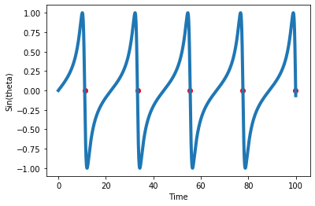

```python
import numpy as np
import matplotlib.pyplot as plt
#NOTE: SOME OF THIS CODE IS ADAPTED FROM CODE PROVIDED EARLIER IN THIS COURSE
#time constant
tau = 1
#input current
I = .02

T = 100      # total time to run
dt = 0.001   # time step
nt = int(np.round(T/dt)+1)     # number of entries in vector array (mV)
tvec = np.linspace(0,T,nt)     # time vector (ms)

#initialize our vector that will keep track of theta
theta = np.zeros(nt)
#the integer detailed in the model for when spikes occur
l = 1
#vector of spike times
st = []
#value of theta at spikes (for graphing purposes)
valThetaAtSpike = []
#preform euler's method
for j in np.arange(nt-1):
    deriv = 1/tau*(1-np.cos(theta[j]))+I*(1+np.cos(theta[j]))
    theta[j+1] = theta[j] + dt*(deriv)
    if theta[j+1] >= (2*l-1)*np.pi and deriv > 0:
        st.append(tvec[j+1])
        valThetaAtSpike.append(np.sin(theta[j+1]))
        l+=1
print("Spike times:")
print(st)
plt.plot(tvec,np.sin(theta), linewidth = 4.0)
plt.scatter(st, valThetaAtSpike, color = "red")
plt.xlabel("Time")
plt.ylabel("Sin(theta)")
plt.show()
```

This figure shows the voltage of a neuron with respect to time and the red dots indicate where spikes occurred.

## Modeling Multiple Neurons From [1]:

To add a notion of synapses the authors of [1] need only add time dependent input currents to the model. Specifically, we will work with the equation: $$ \frac{d\theta_j}{dt} = 1 - cos(\theta_j) + (I_j + \sum_{i=1}^N \alpha_ig_{ij}s_{ij})(1+cos(\theta_j)) $$ Where $I_j$ is an external (not related to the network itself, for instance, some kind of stimulus like light) current. $\alpha_i$ encodes the character of the ith (presynaptic) neuron, which is a one if neuron i is excitatory and a negative 1 if the ith neuron is inhibitory. $g_{ij}$ is the strength of the synaptic connection from neuron i to neuron j. $s_{ij}$ is the synaptic gating variable given to the synapse from neuron i to neuron j. This variable varies in time according to: $$ \frac{ds_{ij}}{dt}=-\frac{s_{ij}}{\tau_{ij}}+exp(-\eta(1+cos(\theta_i))*\frac{1-s_{ij}}{\tau_R} $$ Where $\tau_{ij}$ is the decay time constant. The authors of [1] take $\tau_R$ to be .1 for the rest of the paper, and they assume $\eta$ to be 5 for the rest of the paper. The authors of [1] also note that the above equation is a continuous approximation of the complete equation that would normally be used to model these gating variables. It is normally not continuous because we would expect the gating variable to discontinuously increase whenever a spike occurs in the presynaptic cell, this equation qualitatively replicates this behavior, but does so without discontinuities [1]. An important assumption that the authors make with regards to this equation is that the time constant $\tau_{ij}$ depends only on the presynaptic neuron (neuron i), and that all of the excitatory neurons have the same time constant $\tau_E$ and all the inhibitory neurons have the same time constant $\tau_I$.

## Using this Model In Practice

The authors derived many of the model parameters from experimental data and rules of best practices (for instance having the excitatory neurons make up 80% of the population and inhibitory neurons make up 20% of the population). We will take these same constants when building our models, and a more complete explanation can be found in [1]. The authors generate the connections between E-cells and I-cells according to: $$ g_{ij} = \frac{g_{EI}}{p_{EI}N_E}w_{ij} $$ Where $g_{EI}$ is a constant for all E-cell to I-cell connections, $p_{EI}$ is the probability that there is an E to I-cell connection for a given cell, and $N_E$ is the number of E-cells. $w_{ij}$ is then a 1 with probability $p_{EI}$ and a 0 with probability $1-p_{EI}$. This same equation will apply for E to E-cell connects, I to E cell connections, and I to I-cell connections, only the constants will be changed accordingly (for instance I to E-cells would be generated according to $g_{ij} = \frac{g_{IE}}{p_{IE}N_I}w_{ij}$).

## Model for Circadian Rhythm:

For my extension to this project I will be allowing the synaptic conductance of signals leaving E-cells $g_E$ to vary in time. Again, this approach is warranted by the analysis done in [3] where the permeability of AMPA channels was found to vary with temperature. This means that our new set of differential equations becomes: $$ \frac{d\theta_j}{dt} = 1 - cos(\theta_j) + (I_j + \sum_{i=1}^N \alpha_ig_{ij}(t)s_{ij})(1+cos(\theta_j)) $$ Where $g_{ij}$ is constant if neuron i is not an excitatory neuron, and $g_{ij}(t) = -g_{EI/EE}cos(f*t)$ where f is the frequency and t is the time if i is an excitatory neuron (and $g_{EI/EE}$ is chosen based on the identity of neuron j). This will simply give an oscillating conductance for the outgoing E-signals that has been made to look like the plots of body temperature seen in [2]. For multiple neural networks we will just choose half of the E cells to have one frequency and the other half to have another frequency.

## Achieving Approximate Stability with Non-Uniform E/I-cell Pulses

### I-cell Pulses:

In order to understand PING we must understand how an inhibitory or excitatory pulse can cause synchronized activity. Approximate synchronicity is achieved if we can prove that all the cells in a given population fire within a short time interval. To this end the authors of [1] consider an E-cell population that receives a non-uniform inhibitory pulse. Consider the equation for the jth E-cell in our model (in the case of a non-uniform inhibitory pulse): $$ \frac{d\theta_j}{dt}=(1-cos(\theta_j))+(I-g_js(t))(1+cos(\theta_j)) $$ Where $g_j$ is the strength of the inhibitory pulse to the jth neuron (each $g_j$ is assumed to be independent and normally distributed with mean $\bar{g}$ and standard deviation $\sigma_g$). To find the duration of the volley of spikes the authors consider the following general initial value problem (just the above differential equation written without js): $$ \begin{align} \frac{d\theta}{dt}&=(1-cos(\theta))+(I-gs(t))(1+cos(\theta))\\ \theta(0) &= \theta_0 \end{align} $$ Where g > 0 is a random normal variable with mean $\bar{g}$ and standard deviation $\sigma_g$, and pdf $p_g=p_g(x)$. Since we are assuming only a single pulse we don't need to use the continuous approximation of $s(t)$, and we can instead solve the original differential equation without a jump in it (which is just an equation for exponential decay for t>0 since the only discontinuous jump will be at t=0 which the pulse arrives): $$ \frac{ds}{dt} = -\frac{s}{\tau} $$ The solution to this is simply $e^{-t/\tau}$. This means that we can rewrite this problem as the following initial value problem: $$ \begin{align} \frac{d\theta}{dt}&=(1-cos(\theta))+(I-ge^{-t/\tau})(1+cos(\theta))\\ \theta(0) &= \theta_0 \end{align} $$ To start, the authors of [1] take g as a constant and show why this equation attains stability, then we will come back and find a probabilistic distribution for the synchronized spike time:

To simplify this problem the authors of [1] turn it into a system of differential equations by defining $J(t) = I-ge^{-t/\tau}$. We can note that this is the solution to the initial value problem: $$ \begin{align} \frac{dJ}{dt} &= -\frac{J-I}{\tau_I}\\ J(0) &= I-g \end{align} $$ Quick proof of this fact: $$ \begin{align} \frac{dJ}{dt} &= -\frac{J-I}{\tau_I} \\ \frac{-\tau_I}{J-I}dJ &= dt \\ -\tau_Iln(J-I) &= t + C \\ J-I &= Ae^{-t/\tau_I} \\ J(t) &= Ae^{-t/\tau_I} + I \\ J(0) &= I-g = A + I \\ A &= -g \\ J(t) &= I - ge^{-t/\tau_I} \end{align} $$ So we can rewrite our equation as the following system of equations: $$ \begin{align} \frac{d\theta}{dt}&=(1-cos(\theta))+J(1+cos(\theta))\\ \frac{dJ}{dt} &= -\frac{J-I}{\tau_I}\\ \theta(0) &= \theta_0\\ J(0) &= I-g \end{align} $$ This system is characterized by what is called a river which consists of strongly attracting and strongly repelling streams with a trajectory that the authors of [1] denote as $(\theta_s, J_s)$ which, in this case, is an attracting river for the system. Note: the authors of [1] appear to have found this through simulation, so we will not derive this result. We know the solution of J (because it was defined independent of $\theta$), is $J_s(t) = I - ge^{-t/\tau_I}$. The authors of [1] are then interested in the time T that it takes the system to spike along this trajectory (such that $\theta_s(T) = \pi$. We can use our equation for J to find this time: $$ \begin{align} J_s(T) = J^* &= I - ge^{-t/\tau_I}\\ => -\tau_Iln(\frac{J^*-I}{g})&=T \end{align} $$ This leads the authors of [1] to explain the synchronization of the network: if J is sufficiently negative (in other words g is sufficiently positive because I is always greater than 0) and for $\theta_0$ far from spiking (not close to $\pi$ or any odd multiple of $\pi$) then the system will be attracted toward the river $(J_s,\theta_s)$. Once we are in this river (as the system's attraction to it would imply) then the neuron would spike when $\theta_s = \pi, J_s=J^*$. Then if the neuron is spiking when $J = J^*$ then the neuron will always spike at $-\tau_Iln(\frac{J^*-I}{g})$, so any neurons under these conditions will spike at the same time after getting an inhibitory pulse. Because of the construction of this model (around a limit cycle in 2D) the authors note that this system of equations is periodic, and therefore so is the phase portrait of J and $\theta$, so if $\theta(0)$ is close to spiking (close to $\pi$) it will quickly pass through $\pi$ and then it will be attracted to the river $\theta_s+2\pi, J_s$. We know it will pass quickly through $\pi$ if $\theta_0$ is close to $\pi$ because this is close to a spike and looking at the simulation above (of spike times of a neuron), we can see that the theta value of the neuron will be moving fast around this initial condition. This means that the neuron will spike soon after time 0, and then spike again when $J = J^*$ meaning at time $T = -\tau_Iln(\frac{J^*-I}{g})$, which will still give synchronized behavior. There is a narrow band of initial values for which we do not get synchronized behavior, and while this is not extremely relevant for the rest of the rest of [1] I would like to briefly discuss this since it changed the way that I simulated the model described in [1].

The initialization that I do in the model is not completely random across the whole interval of possible theta starting values, because for some simulations the synchronization would not be achieved for a small number of neurons. I assume that these neurons lay in the small problematic interval where a neuron does not achieve synchronization described above, so I have limited the random initialization to values where this is not a problem for simulation (in the case of an ideal network).

The authors of [1] now return to the idea of g being a random variable. The authors are interested in the distribution of the synchronized spike times $T$ which were found to be $-\tau_Iln(\frac{J^*-I}{g})$. Since g is the only random quantity in this formula the authors of [1] use log rules to get it by itself: $$ \begin{align} T &= -\tau_Iln(\frac{J^*-I}{g})\\ &= \tau_Iln(g)-\tau_Iln(I-J^*) \end{align} $$ Seeing the equation written in this form clearly shows that we need to consider the pdf of a random variable that the authors define as $X = ln(g)$. To find the pdf of this distribution the authors of [1] consider: $$ \begin{align} P(a<X<b) &= P(a<ln(g)<b) = P(e^a<g<e^b)\\ &= \int_{e^a}^{e^b}p_g(x)dx \end{align} $$ Doing a u substitution where $u = ln(x), du = 1/xdx$ gives new bounds of $ln(e^a) = a$ and $ln(e^b) = b$ and $x = e^u, dx = xdu = e^udu$. So we can rewrite this integral as: $$ \int_{e^a}^{e^b}p_g(x)dx = \int_{a}^{b}e^up_g(e^u)du $$ The integrand is the pdf of X, so we get that X has pdf $p_X(x) = e^xp_g(e^x)$. The authors of [1] note that if $\sigma_g$ is sufficiently small we can approximate $\sigma_X$ as $\sigma_g/\bar{g}$. A quick proof of this (adapted from [4]): $$ \begin{align} var(X) = var(ln(g)) &= var(ln(\bar{g} + (g - \bar{g}))) \\ &\approx var(ln(\bar{g})+ln'(\bar{g})(g-\bar{g})+O(g^2)) \end{align} $$ For sufficiently small $\sigma_g$ the first order approximation is accurate, so: $$ \begin{align} &var(ln(\bar{g})+ln'(\bar{g})(g-\bar{g})+O(g^2)) \\ &\approx var(ln(\bar{g})+ln'(\bar{g})(g-\bar{g}))\\ &= ln'(\bar{g})^2var(g) = \sigma_g^2/(\bar{g}^2) \end{align} $$ Taking the square root of the variance gives us the desired result, so the standard deviation of X is approximately $\sigma_X = \frac{\sigma_g}{\bar{g}}$.

The authors now use the equation for $T$ to get a pdf for the time of synchronized spikes after an inhibitory pulse: $$ \begin{align} P(a<T<b) &= P(a<\tau_Iln(g)-\tau_Iln(I-J^*)<b)\\ &=P(\frac{a+\tau_Iln(I-J^*)}{\tau_I}<X<\frac{b+\tau_Iln(I-J^*)}{\tau_I})\\ &= \int_{\frac{a+\tau_Iln(I-J^*)}{\tau_I}}^{\frac{b+\tau_Iln(I-J^*)}{\tau_I}}e^up_g(e^u)du \end{align} $$ Using the substitution $t = \tau_Iu-\tau_Iln(I-J^*), dt = \tau_Idu$. This will change the bounds of integration to be from a to b, and we will note that $(t+\tau_Iln(I-J^*))/\tau_I = u$ so we can rewrite the integral as: $$ \int_{\frac{a+\tau_Iln(I-J^*)}{\tau_I}}^{\frac{b+\tau_Iln(I-J^*)}{\tau_I}}e^up_g(e^u)du = \int_{a}^{b}e^{(t+\tau_Iln(I-J^*))/\tau_I}p_g(e^{(t+\tau_Iln(I-J^*))/\tau_I})/\tau_Idt $$ So T has pdf $e^{(t+\tau_Iln(I-J^*))/\tau_I}p_g(e^{(t+\tau_Iln(I-J^*))/\tau_I})/\tau_I$. This pdf only applies for pulses that start at t = 0, generalizing to a pulse that starts at $t = T_0$ we get a pdf of T (the time after the pulse that it takes for the next synchronized spike) as: $e^{(t-T_0+\tau_Iln(I-J^*))/\tau_I}p_g(e^{(t-T_0+\tau_Iln(I-J^*))/\tau_I})/\tau_I$. To get the standard deviation of this the authors of [1] simply note that T is a linear transformation of X, so $\sigma_T = \sigma_X\tau_I = \tau_I\frac{\sigma_g}{\bar{g}}$. Intuitively $\sigma_T$ should be a measure of the length of the synchronized spike volley since most of the spikes will happen within a single standard deviation of T, so we will think of $\sigma_T$ as the duration of this volley. Keep note of the distribution of T, because we will refer to it later in the results portion of this paper.

### E-cell Pulses

This section in [1] is much the same as the I-cell pulse synchronization. The goal is still to prove that all of the neurons will eventually spike at the same time, but because of the nature of this problem stronger assumptions must be made. For this reason the authors don't use the results from this section nearly as much as the results from the previous section, and also for this reason we will summarize the results of this section without doing the full derivations.

The authors of [1] find that synchronized behavior is also predicted after an E-cell pulse, but in order to find specific expressions for quantities of interest (like the duration of the spike volley in approximately synchronized behavior, as well as the time $T$ after the pulse that synchronized behavior is predicted) the authors make a few assumptions. They first assume that the time constant for the gating variable $\tau_E$ is infinity (which would make $s(t) \approx 1$ for all time). They also assume that $g$ is very large in order to make their first assumption reasonable. If both of these are true and the I-cells only receive input from the E-cells (not external input $I$) then they find that the time $T$ to spike is: $T = \frac{\pi}{2\sqrt{g}}$.

They then make g into a random variable (in the same way that we did in I-cell pulses), and they find that the expected duration of a spike volly following an excitatory pulse is $\sigma_T \approx \frac{\pi \sigma_g}{4*\bar{g}^{3/2}}$ which again shows us that decreasing the variance of the input to each cell $\sigma_g$ or increasing the mean strength of the inputs $\bar{g}$ will give tighter synchronicity.

It should be noted that this network was constructed in such a way that the variance of g and the mean of g are directly related. Because each input is the same for the network described in the methods section the strength of g is completely determined by how many inputs are given to the cell. This means that for sparser networks there is less input expected to each cell, so $\bar{g}$ will be lower. Then, consider an almost fully connected network (with the probability of 2 neurons being connected as .99). In a network of 100 neurons we would expect that each neuron would have 99 connections. Since the number of connections that a particular neuron will make is a binomial random variable with n = 100 and p =.99 we know that the standard deviation is $\sqrt{np(1-p)}\approx .995$. If we then take the probability of connection to be .5 we would get a mean of 50 connections with a standard deviation of approximately 5. So sparser networks will not only have a lower expected g, but also g will have a larger variance/standard deviation.

### Application of these Results to Values of g that Vary in Time:

I would just like to offer a quick explanation as to why the previous results still apply when we allow g to vary in time. If we set the frequency at which g varies to be much slower than the time it takes a neuron to spike and much slower than the time between synchronizing pluses and the following synchronized spike volley then we can treat $g$ as a constant, meaning the same analysis will apply.

# Results

## From [1]

Using the methods above we can talk about the PING mechanism in more detail. To start, the authors of [1] describe the conditions under which the PING mechanism applies.

- "Condition 1: The E-cells receive external input significantly above their spiking threshold." (quoted from [1]). This should make some intuitive sense since we need the system to have some activity at rest.
- "Condition 2: The E -> I synapses are so strong and have so short a rise time that a surge in spiking of the E-cells quickly triggers a surge in spiking of the I-cells." (quoted from [1]). In the previous section we found that the length of a synchronized spike volley was inversely proportional to $g^{3/2}$ (g being the synaptic strength between the E and the I synapses in this case). This means that we have tighter synchronicity when the E->I synapses are stronger, so it would make sense for PING to involve these connections.
- "Condition 3: The I-cells spike only in response to the E-cells" (quoted from [1]). This was an assumption that was made during our discussion on E-cell pulses causing synchronization when we set the external input to zero.
- "Condition 4: the I->E synapses are so strong that a population spike of the I-cells approximately synchronizes the E-cells." (quoted from [1]). We showed the necessity for this condition in our discussion of an inhibitory pulse synchronizing a network. We found that g (the synaptic strength of the I-cells to the E-cells) needed to be high enough for J to be sufficiently negative in order for the system to be attracted to the stable river that made synchronization possible.

With each of these conditions in mind the authors talk about how the PING mechanism works: first, due to the activity induced in the E-cells by the external input (see condition 1) activity in the I-cells will begin (see condition 2). The new I-cell activity will cause the E-cells to stop spiking (see condition 4), which will remove any input from the I-cells (see condition 3) which will cause them to stop spiking as well. Then, a period where neither population can spike (the E-cells are still waiting for their inhibition to wear off, and the I-cells are not receiving any input) is followed by the E-cells resuming their spiking, except they are synchronized (for the same reasons for our discussion of inhibitory pulses causing synchronization). Then the drive from the E-cells now acts as an excitatory pulse which also brings the I-cells closer to synchronicity. Below we replicate figure 7 from [1], which shows the behavior of the network when each condition from above is violated.

```python
import numpy as np
import matplotlib.pyplot as plt
#NOTE: SOME OF THIS CODE IS ADAPTED FROM CODE PROVIDED EARLIER IN THIS COURSE
T = 200      # total time to run
dt = 0.1   # time step
nt = int(np.round(T/dt)+1)     # number of entries in vector array (mV)
tvec = np.linspace(0,T,nt)     # time vector (ms)

N = 100 #number of neurons in our network
vecOfNeurons = np.zeros((N, 2)) #stores the activation of neuron j in column 1 and the type in column 2
vecOfNeurons[0:int(np.floor(.8*N)), 1] = 1 #1 for excitatory, -1 for inhibitory
vecOfNeurons[int(np.floor(.8*N)):N, 1] = -1
Ne = int(np.floor(.8*N)) #number of excitatory neurons in the network
Ni = N - Ne #number of inhibitory neurons in the network

#Randomly initialize each neuron:
for i in range(0,N):
    num = np.random.uniform(0,2*np.pi)
    vecOfNeurons[i,0] = num

#Contruct a matrix of the connections between neurons
#start with the connections between the excitatory neurons
#(wij such that 0<=i<=np.floor(.8*N), and 0<=j<=np.floor(.8*N))
W = np.zeros((N,N))

#EE connections:
gEE = 0 #Scales the conductivity
pEE = 0 #probability that a given E neuron is connected to another E neuron
for i in range(0, int(np.floor(.8*N))):
    for j in range(0, int(np.floor(.8*N))):
        num = np.random.uniform(0,1)
        #Make a connection with probability pEE
        if num < pEE:
            W[i,j] = gEE/(Ne*pEE)

#EI connections:
gEI = .05 #Scales the conductivity
pEI = 1 #probability that a given E neuron is connected to another I neuron
for i in range(0,int(np.floor(.8*N))):
    for j in range(int(np.floor(.8*N)), N):
        num = np.random.uniform(0,1)
        #Make a connection with probability pEE
        if num < pEI:
            W[i,j] = gEI/(Ne*pEI)

#IE Connections
gIE = .25 #Scales the conductivity
pIE = 1 #probability that a given E neuron is connected to another I neuron
for i in range(int(np.floor(.8*N)),N):
    for j in range(0, int(np.floor(.8*N))):
        num = np.random.uniform(0,1)
        #Make a connection with probability pEE
        if num < pIE:
            W[i,j] = gIE/(Ni*pIE)

#II connections
gII = 0 #Scales the conductivity
pII = 0 #probability that a given E neuron is connected to another I neuron
for i in range(int(np.floor(.8*N)), N):
    for j in range(int(np.floor(.8*N)), N):
        num = np.random.uniform(0,1)
        #Make a connection with probability pEE
        if num < pII:
            W[i,j] = gII/(Ni*pII)
#Simulate the differential equations using forward euler:
S = np.zeros((N,N)) #Gating variable

#Initializing all the constants
IE = .1 #external forcing on the E neurons
II = 0 #external forcing on the I neurons
I = 0 #temp to be used in the loops
l=np.ones(N) #used for finding spike times (every time theta = (2l-1)pi and derivative is > 0, for each neuron)
tauE = 2 #time constant for the excitatory population
tauI = 10 #time constant for the inhibitory population
tauR = .1 #time constant for S
nu = 5 #parameter that appears in S
tau = 0 #Initializeing a temp tau for updating S

#Keep track of which neuron spiked and spike times:
neuronSpiked = []
spikeTime = []

#Step through time:
for j in np.arange(nt-1):
    #Step through each neuron
    for i in range(0, N):
        #Choose external forcing depending on what neuron we are updating
        if vecOfNeurons[i,1] == 1:
            I = IE
        else:
            I = II
        deriv = (1-np.cos(vecOfNeurons[i,0]) + (I +
            np.sum(np.multiply(np.multiply(vecOfNeurons[:,1], W[:,i]), S[:,i])))* (1+np.cos(vecOfNeurons[i,0])))
        vecOfNeurons[i,0] = vecOfNeurons[i,0] + dt* deriv
        if vecOfNeurons[i,0] >= (2*l[i]-1)*np.pi and deriv > 0:
            neuronSpiked.append(i)
            spikeTime.append(tvec[j+1])
            l[i]+=1
    #Update our gating variables:
    for i in range(0,N):
        for k in range(0,N):
            #choose time constant in the formula
            if vecOfNeurons[i,1] == 1:
                tau = tauE
            else:
                tau = tauI
            deriv = -1*S[i,k]/tau+np.exp(-nu*(1+np.cos(vecOfNeurons[i,0])))*(1-S[i,k])/tauR
            S[i,k] = S[i,k]+dt*deriv

fig, axs = plt.subplots(2, 2, figsize=(10, 10))
plt.subplot(221)
plt.title("A")
plt.xlabel("Time")
plt.ylabel("Cell Number")
plt.scatter(spikeTime, neuronSpiked, color = "red")

vecOfNeurons = np.zeros((N, 2)) #stores the activation of neuron j in column 1 and the type in column 2
vecOfNeurons[0:int(np.floor(.8*N)), 1] = 1 #1 for excitatory, -1 for inhibitory
vecOfNeurons[int(np.floor(.8*N)):N, 1] = -1
Ne = int(np.floor(.8*N)) #number of excitatory neurons in the network
Ni = N - Ne #number of inhibitory neurons in the network

#Randomly initialize each neuron:
for i in range(0,N):
    num = np.random.uniform(0,2*np.pi)
    vecOfNeurons[i,0] = num

#Contruct a matrix of the connections between neurons
#start with the connections between the excitatory neurons
#(wij such that 0<=i<=np.floor(.8*N), and 0<=j<=np.floor(.8*N))
W = np.zeros((N,N))

#EE connections:
gEE = 0 #Scales the conductivity
pEE = 0 #probability that a given E neuron is connected to another E neuron
for i in range(0, int(np.floor(.8*N))):
    for j in range(0, int(np.floor(.8*N))):
        num = np.random.uniform(0,1)
        #Make a connection with probability pEE
        if num < pEE:
            W[i,j] = gEE/(Ne*pEE)

#EI connections:
gEI = .25 #Scales the conductivity
pEI = 1 #probability that a given E neuron is connected to another I neuron
for i in range(0,int(np.floor(.8*N))):
    for j in range(int(np.floor(.8*N)), N):
        num = np.random.uniform(0,1)
        #Make a connection with probability pEE
        if num < pEI:
            W[i,j] = gEI/(Ne*pEI)

#IE Connections
gIE = .25 #Scales the conductivity
pIE = 1 #probability that a given E neuron is connected to another I neuron
for i in range(int(np.floor(.8*N)),N):
    for j in range(0, int(np.floor(.8*N))):
        num = np.random.uniform(0,1)
        #Make a connection with probability pEE
        if num < pIE:
            W[i,j] = gIE/(Ni*pIE)
```

```python
#II connections
gII = 0 #Scales the conductivity
pII = 0 #probability that a given E neuron is connected to another I neuron
for i in range(int(np.floor(.8*N)), N):
    for j in range(int(np.floor(.8*N)), N):
        num = np.random.uniform(0,1)
        #Make a connection with probability pEE
        if num < pII:
            W[i,j] = gII/(Ni*pII)
#Simulate the differential equations using forward euler:
S = np.zeros((N,N)) #Gating variable

#Initializing all the constants
IE = .1 #external forcing on the E neurons
II = .05 #external forcing on the I neurons
I = 0 #temp to be used in the loops
l=np.ones(N) #used for finding spike times (every time theta = (2l-1)pi and derivative is > 0, for each neuron)
tauE = 2 #time constant for the excitatory population
tauI = 10 #time constant for the inhibitory population
tauR = .1 #time constant for S
nu = 5 #parameter that appears in S
tau = 0 #Initializeing a temp tau for updating S

#Keep track of which neuron spiked and spike times:
neuronSpiked = []
spikeTime = []

#Step through time:
for j in np.arange(nt-1):
    #Step through each neuron
    for i in range(0, N):
        #Choose external forcing depending on what neuron we are updating
        if vecOfNeurons[i,1] == 1:
            I = IE
        else:
            I = II
        deriv = (1-np.cos(vecOfNeurons[i,0]) + (I +
            np.sum(np.multiply(np.multiply(vecOfNeurons[:,1], W[:,i]), S[:,i])))* (1+np.cos(vecOfNeurons[i,0])))
        vecOfNeurons[i,0] = vecOfNeurons[i,0] + dt* deriv
        if vecOfNeurons[i,0] >= (2*l[i]-1)*np.pi and deriv > 0:
            neuronSpiked.append(i)
            spikeTime.append(tvec[j+1])
            l[i]+=1
    #Update our gating variables:
    for i in range(0,N):
        for k in range(0,N):
            #choose time constant in the formula
            if vecOfNeurons[i,1] == 1:
                tau = tauE
            else:
                tau = tauI
            deriv = -1*S[i,k]/tau+np.exp(-nu*(1+np.cos(vecOfNeurons[i,0])))*(1-S[i,k])/tauR
            S[i,k] = S[i,k]+dt*deriv

plt.subplot(222)
plt.title("B")
plt.xlabel("Time")
plt.ylabel("Cell Number")
plt.scatter(spikeTime, neuronSpiked, color = "red")

vecOfNeurons = np.zeros((N, 2)) #stores the activation of neuron j in column 1 and the type in column 2
vecOfNeurons[0:int(np.floor(.8*N)), 1] = 1 #1 for excitatory, -1 for inhibitory
vecOfNeurons[int(np.floor(.8*N)):N, 1] = -1
Ne = int(np.floor(.8*N)) #number of excitatory neurons in the network
Ni = N - Ne #number of inhibitory neurons in the network

#Randomly initialize each neuron:
for i in range(0,N):
    num = np.random.uniform(0,2*np.pi)
    vecOfNeurons[i,0] = num

#Contruct a matrix of the connections between neurons
#start with the connections between the excitatory neurons
#(wij such that 0<=i<=np.floor(.8*N), and 0<=j<=np.floor(.8*N))
W = np.zeros((N,N))

#EE connections:
gEE = 0 #Scales the conductivity
pEE = 0 #probability that a given E neuron is connected to another E neuron
for i in range(0, int(np.floor(.8*N))):
    for j in range(0, int(np.floor(.8*N))):
        num = np.random.uniform(0,1)
        #Make a connection with probability pEE
        if num < pEE:
            W[i,j] = gEE/(Ne*pEE)

#EI connections:
gEI = .25 #Scales the conductivity
pEI = 1 #probability that a given E neuron is connected to another I neuron
for i in range(0,int(np.floor(.8*N))):
    for j in range(int(np.floor(.8*N)), N):
        num = np.random.uniform(0,1)
        #Make a connection with probability pEE
        if num < pEI:
            W[i,j] = gEI/(Ne*pEI)

#IE Connections
gIE = .25 #Scales the conductivity
pIE = 1 #probability that a given E neuron is connected to another I neuron
for i in range(int(np.floor(.8*N)),N):
    for j in range(0, int(np.floor(.8*N))):
        num = np.random.uniform(0,1)
        #Make a connection with probability pEE
        if num < pIE:
            W[i,j] = gIE/(Ni*pIE)

#II connections
gII = 0.25 #Scales the conductivity
pII = 1 #probability that a given E neuron is connected to another I neuron
for i in range(int(np.floor(.8*N)), N):
    for j in range(int(np.floor(.8*N)), N):
        num = np.random.uniform(0,1)
        #Make a connection with probability pEE
        if num < pII:
            W[i,j] = gII/(Ni*pII)
#Simulate the differential equations using forward euler:
S = np.zeros((N,N)) #Gating variable

#Initializing all the constants
IE = .1 #external forcing on the E neurons
II = .05 #external forcing on the I neurons
I = 0 #temp to be used in the loops
l=np.ones(N) #used for finding spike times (every time theta = (2l-1)pi and derivative is > 0, for each neuron)
tauE = 2 #time constant for the excitatory population
tauI = 10 #time constant for the inhibitory population
tauR = .1 #time constant for S
nu = 5 #parameter that appears in S
tau = 0 #Initializeing a temp tau for updating S

#Keep track of which neuron spiked and spike times:
neuronSpiked = []
spikeTime = []

#Step through time:
for j in np.arange(nt-1):
    #Step through each neuron
    for i in range(0, N):
        #Choose external forcing depending on what neuron we are updating
        if vecOfNeurons[i,1] == 1:
            I = IE
        else:
            I = II
        deriv = (1-np.cos(vecOfNeurons[i,0]) + (I +
            np.sum(np.multiply(np.multiply(vecOfNeurons[:,1], W[:,i]), S[:,i])))* (1+np.cos(vecOfNeurons[i,0])))
        vecOfNeurons[i,0] = vecOfNeurons[i,0] + dt* deriv
        if vecOfNeurons[i,0] >= (2*l[i]-1)*np.pi and deriv > 0:
            neuronSpiked.append(i)
            spikeTime.append(tvec[j+1])
            l[i]+=1
    #Update our gating variables:
    for i in range(0,N):
        for k in range(0,N):
            #choose time constant in the formula
            if vecOfNeurons[i,1] == 1:
                tau = tauE
            else:
                tau = tauI
            deriv = -1*S[i,k]/tau+np.exp(-nu*(1+np.cos(vecOfNeurons[i,0])))*(1-S[i,k])/tauR
            S[i,k] = S[i,k]+dt*deriv

plt.subplot(223)
plt.title("C")
plt.xlabel("Time")
plt.ylabel("Cell Number")
plt.scatter(spikeTime, neuronSpiked, color = "red")
```

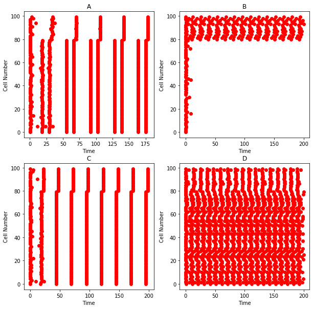

```python
vecOfNeurons = np.zeros((N, 2)) #stores the activation of neuron j in column 1 and the type in column 2
vecOfNeurons[0:int(np.floor(.8*N)), 1] = 1 #1 for excitatory, -1 for inhibitory
vecOfNeurons[int(np.floor(.8*N)):N, 1] = -1
Ne = int(np.floor(.8*N)) #number of excitatory neurons in the network
Ni = N - Ne #number of inhibitory neurons in the network

#Randomly initialize each neuron:
for i in range(0,N):
    num = np.random.uniform(0,2*np.pi)
    vecOfNeurons[i,0] = num

#Contruct a matrix of the connections between neurons
#start with the connections between the excitatory neurons
#(wij such that 0<=i<=np.floor(.8*N), and 0<=j<=np.floor(.8*N))
W = np.zeros((N,N))

#EE connections:
gEE = 0 #Scales the conductivity
pEE = 0 #probability that a given E neuron is connected to another E neuron
for i in range(0, int(np.floor(.8*N))):
    for j in range(0, int(np.floor(.8*N))):
        num = np.random.uniform(0,1)
        #Make a connection with probability pEE
        if num < pEE:
            W[i,j] = gEE/(Ne*pEE)

#EI connections:
gEI = .25 #Scales the conductivity
pEI = 1 #probability that a given E neuron is connected to another I neuron
for i in range(0,int(np.floor(.8*N))):
    for j in range(int(np.floor(.8*N)), N):
        num = np.random.uniform(0,1)
        #Make a connection with probability pEE
        if num < pEI:
            W[i,j] = gEI/(Ne*pEI)

#IE Connections
gIE = .005 #Scales the conductivity
pIE = 1 #probability that a given E neuron is connected to another I neuron
for i in range(int(np.floor(.8*N)),N):
    for j in range(0, int(np.floor(.8*N))):
        num = np.random.uniform(0,1)
        #Make a connection with probability pEE
        if num < pIE:
            W[i,j] = gIE/(Ni*pIE)

#II connections
gII = 0 #Scales the conductivity
pII = 0 #probability that a given E neuron is connected to another I neuron
for i in range(int(np.floor(.8*N)), N):
    for j in range(int(np.floor(.8*N)), N):
        num = np.random.uniform(0,1)
        #Make a connection with probability pEE
        if num < pII:
            W[i,j] = gII/(Ni*pII)
#Simulate the differential equations using forward euler:
S = np.zeros((N,N)) #Gating variable

#Initializing all the constants
IE = .1 #external forcing on the E neurons
II = 0 #external forcing on the I neurons
I = 0 #temp to be used in the loops
l=np.ones(N) #used for finding spike times (every time theta = (2l-1)pi and derivative is > 0, for each neuron)
tauE = 2 #time constant for the excitatory population
tauI = 10 #time constant for the inhibitory population
tauR = .1 #time constant for S
nu = 5 #parameter that appears in S
tau = 0 #Initializeing a temp tau for updating S

#Keep track of which neuron spiked and spike times:
neuronSpiked = []
spikeTime = []

#Step through time:
for j in np.arange(nt-1):
    #Step through each neuron
    for i in range(0, N):
        #Choose external forcing depending on what neuron we are updating
        if vecOfNeurons[i,1] == 1:
            I = IE
        else:
            I = II
        deriv = (1-np.cos(vecOfNeurons[i,0]) + (I +
            np.sum(np.multiply(np.multiply(vecOfNeurons[:,1], W[:,i]), S[:,i])))* (1+np.cos(vecOfNeurons[i,0])))
        vecOfNeurons[i,0] = vecOfNeurons[i,0] + dt* deriv
        if vecOfNeurons[i,0] >= (2*l[i]-1)*np.pi and deriv > 0:
            neuronSpiked.append(i)
            spikeTime.append(tvec[j+1])
            l[i]+=1
    #Update our gating variables:
    for i in range(0,N):
        for k in range(0,N):
            #choose time constant in the formula
            if vecOfNeurons[i,1] == 1:
                tau = tauE
            else:
                tau = tauI
            deriv = -1*S[i,k]/tau+np.exp(-nu*(1+np.cos(vecOfNeurons[i,0])))*(1-S[i,k])/tauR
            S[i,k] = S[i,k]+dt*deriv

plt.subplot(224)
plt.title("D")
plt.xlabel("Time")
plt.ylabel("Cell Number")
plt.scatter(spikeTime, neuronSpiked, color = "red")
plt.show()
```

Note: each of these plots show both the I-cells and the E-cells on the same graph. We used parameters described by [1], so 20% of the neurons are I-cells and 80% are E-cells. In this case neurons numbered 80-100 are I-cells, and the rest are E-cells.

Subplot A of the above figure shows what happens when synapses between E-cells and I-cells lose strength. You can see that the two populations still reach some kind of synchronized behavior, but without the inhibition from the I-cells the E-cells are able to spike multiple times in between the spikes of the I-cell population's spikes. This is because the I-cells are not being sufficiently stimulated, so the time between I-cell spikes is very long. This means that the inhibition wears off in the E-cells and they are able to spike again (though they are still synchronized).

Subplot B shows what happens if the I-cells are externally stimulated. We can see a great deal of spiking in I-cells, but none of the E-cells are able to spike (after their first set of spikes) due to the inhibition generated by the increase in I-cell spiking.

Subplot C shows that synchronized behavior is possible with external forcing of I-cells if we add I to I-cell synapses. Presumably this begins to self-regulate the over-activity of the I-cells, and gives the E-cells a chance to spike again.

Subplot D shows that synchronicity is lost if the I to E-cell synapses are too weak. With too little inhibition on the E-cells they can spike as much as possible without being inhibited. Since the I-cells are receiving a ton of input from the E-cells, they are also able to spike a lot, but not enough to actually stop the E-cells.

Briefly, I would like to talk about the implications of this analysis to my project's extension to circadian rhythm. Because the current research in [3] suggests that AMPA receptors are affected by temperature we can reasonably model this as fluctuations in the synaptic strength between E and I cells (see subplot A), so our analog for circadian rhythm will always be synchronized to some extent, but the rate of firing in the E-cells will be faster when the network is "desynchronized" then when it is "synchronized".

Next, we would like to see how well the distribution of approximately synchronized spikes fits our predicted distribution. Recall from the previous section that the distribution of spike times after an inhibitory pulse is: $$ \rho_T(t) = \frac{1}{\tau_I}e^{(t-T_0+\tau_Iln(I-J^*))/\tau_I}\rho_g(e^{(t-T_0+\tau_Iln(I-J^*))/\tau_I}) $$ Since we do not have an explicit formula for $J^*$ the authors of [1] approximate this: $$ \begin{align} T&=\tau_IX-\tau_Iln(I-J^*)\\ =>E(T)&=E(\tau_IX-\tau_Iln(I-J^*))\\ =>\tau_Iln(I-J^*)&=\tau_IE(X)-E(T) \end{align} $$ Approximate $E(X)$ using taylor series (proof adapted from [4]): $$ \begin{align} E(X) = E(ln(g)) &= E(ln(\bar{g}+(g-\bar{g})))\\ &\approx E(ln(\bar{g})+ln'(\bar{g})(g-\bar{g})+\frac{1}{2}ln''(\bar{g})(g-\bar{g})^2)\\ &=ln(\bar{g})+ln''(\bar{g})/2*\sigma_g^2 \end{align} $$ If $\sigma_g^2$ is small: $$ E(X) \approx ln(\bar{g}) $$ Using this approximation we get: $$ \tau_Iln(I-J^*)\approx\tau_Iln(\bar{g})-E(T) $$ Since we can approximate $E(T)$ from the results of a simulation the above approximation will be sufficient for the authors of [1], except that it assumes that the inhibitory pulse will arrive at $T=0$. For an inhibitory pulse arriving at an arbitrary time $T=T_0$ we have: $$ \tau_Iln(I-J^*)\approx\tau_Iln(\bar{g})+T_0-E(T) $$ Finally, we can note that $\bar{g} \approx g_{IE}$ (given by [1]) since this is what we are setting the synaptic strength of the I-cell to E-cell connections. Putting all of this together we wrote the following simulation which reproduces figure 8 from [1]:

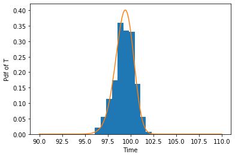

```python
import numpy as np
import matplotlib.pyplot as plt
#NOTE: SOME OF THIS CODE IS ADAPTED FROM CODE PROVIDED EARLIER IN THIS COURSE
T = 200      # total time to run
dt = 0.1   # time step
nt = int(np.round(T/dt)+1)     # number of entries in vector array (mV)
tvec = np.linspace(0,T,nt)     # time vector (ms)

N = 500 #number of neurons in our network
vecOfNeurons = np.zeros((N, 2)) #stores the activation of neuron j in column 1 and the type in column 2
vecOfNeurons[0:int(np.floor(.8*N)), 1] = 1 #1 for excitatory, -1 for inhibitory
vecOfNeurons[int(np.floor(.8*N)):N, 1] = -1
Ne = int(np.floor(.8*N)) #number of excitatory neurons in the network
Ni = N - Ne #number of inhibitory neurons in the network

#Randomly initialize each neuron:
for i in range(0,N):
    num = np.random.uniform(0,2*np.pi/3)
    vecOfNeurons[i,0] = num

#Contruct a matrix of the connections between neurons
#start with the connections between the excitatory neurons
#(wij such that 0<=i<=np.floor(.8*N), and 0<=j<=np.floor(.8*N))
W = np.zeros((N,N))

#EE connections:
gEE = 0 #Scales the conductivity
pEE = 0 #probability that a given E neuron is connected to another E neuron
for i in range(0, int(np.floor(.8*N))):
    for j in range(0, int(np.floor(.8*N))):
        num = np.random.uniform(0,1)
        #Make a connection with probability pEE
        if num < pEE:
            W[i,j] = gEE/(Ne*pEE)

#EI connections:
gEI = .25 #Scales the conductivity
pEI = .5 #probability that a given E neuron is connected to another I neuron
for i in range(0,int(np.floor(.8*N))):
    for j in range(int(np.floor(.8*N)), N):
        num = np.random.uniform(0,1)
        #Make a connection with probability pEE
        if num < pEI:
            W[i,j] = gEI/(Ne*pEI)

#IE Connections
gIE = .25 #Scales the conductivity
pIE = .5 #probability that a given E neuron is connected to another I neuron
for i in range(int(np.floor(.8*N)),N):
    for j in range(0, int(np.floor(.8*N))):
        num = np.random.uniform(0,1)
        #Make a connection with probability pEE
        if num < pIE:
            W[i,j] = gIE/(Ni*pIE)

#II connections
gII = 0 #Scales the conductivity
pII = 0 #probability that a given E neuron is connected to another I neuron
for i in range(int(np.floor(.8*N)), N):
    for j in range(int(np.floor(.8*N)), N):
        num = np.random.uniform(0,1)
        #Make a connection with probability pEE
        if num < pII:
            W[i,j] = gII/(Ni*pII)
#Simulate the differential equations using forward euler:
S = np.zeros((N,N)) #Gating variable

#Initializing all the constants
IE = .1 #external forcing on the E neurons
II = 0 #external forcing on the I neurons
I = 0 #temp to be used in the loops
l=np.ones(N) #used for finding spike times (every time theta = (2l-1)pi and derivative is > 0, for each neuron)
tauE = 2 #time constant for the excitatory population
tauI = 10 #time constant for the inhibitory population
tauR = .1 #time constant for S
nu = 5 #parameter that appears in S
tau = 0 #Initializeing a temp tau for updating S

#Keep track of which neuron spiked and spike times:
neuronSpiked = []
spikeTime = []
spikeAfter100 = []
#Step through time:
for j in np.arange(nt-1):
    #Step through each neuron
    for i in range(0, N):
        #Choose external forcing depending on what neuron we are updating
        if vecOfNeurons[i,1] == 1:
            I = IE
        else:
            I = II
        deriv = (1-np.cos(vecOfNeurons[i,0]) + (I +
            np.sum(np.multiply(np.multiply(vecOfNeurons[:,1], W[:,i]), S[:,i])))* (1+np.cos(vecOfNeurons[i,0])))
        vecOfNeurons[i,0] = vecOfNeurons[i,0] + dt* deriv
        if vecOfNeurons[i,0] >= (2*l[i]-1)*np.pi and deriv > 0:
            neuronSpiked.append(i)
            spikeTime.append(tvec[j+1])
            l[i]+=1
            if tvec[j+1] > 90 and tvec[j+1] < 115 and vecOfNeurons[i,1]==1:
                spikeAfter100.append(tvec[j+1])

    #Update our gating variables:
    for i in range(0,N):
        for k in range(0,N):
            #choose time constant in the formula
            if vecOfNeurons[i,1] == 1:
                tau = tauE
            else:
                tau = tauI
            deriv = -1*S[i,k]/tau+np.exp(-nu*(1+np.cos(vecOfNeurons[i,0])))*(1-S[i,k])/tauR
            S[i,k] = S[i,k]+dt*deriv
tVec = np.linspace(90,110, num = 500)
temp = np.mean(spikeAfter100)-tauI*np.log(gIE)
approxShape = 1/tauI*np.exp((tVec-temp)/tauI)*(1/(
    .025*np.sqrt(2*np.pi)))*np.exp(-.5*((np.exp((tVec-temp)/tauI)
                                         -.25)/.025)**2)
plt.hist(spikeAfter100, density = True)
plt.plot(tVec, approxShape)
plt.xlabel("Time")
plt.ylabel("Pdf of T")
plt.show()
```

The above figure shows the density histogram of a single approximately synchronized spike volley, along with what the previous analysis predicts the pdf of $T$ should be (the curve overlaying the histogram). This shows the approximate spike distribution that was derived is approximately correct.

Again, I would like to talk about some implications that this has to the extension that I will do for this project. In order to predict an episode of sleep we will need to come up with a metric that can tell us at what times there was synchronized spiking and at what times there is asynchronized spiking. Ultimately we will simply look at the number of neurons that spike in an interval of time (as we would expect more neurons to spike during asynchronized activity), but the above figure (and analysis related to the derivation of the pdf of the spike times and the predicted duration of the spike volley) tells us that we could also use the variance of the spike times to tell whether or not the spikes were synchronized, or we could use some measure of fit to the predicted pdf of T assuming spikes were synchronized vs what was actually observed.

## From my extension:

To start I will analyze a single neural network with fluctuations in the E-cell's conductance. I am primarily interested in verifying that synchronized and desynchronized behavior will occur where we expect them to (desynchronized behavior at temperature troughs and synchronized activity at temperature peaks see [2] for more details). I would also like to look at histograms of neural activity during synchronized and asynchronized activity to verify that using the number of neurons spiking in a given time interval would be a good measure of whether or not we are in a period of synchronized or unsynchronized activity. Finally I will look at a density plot of asynchronized activity so I can compare it to the density plot that we simulated last section.

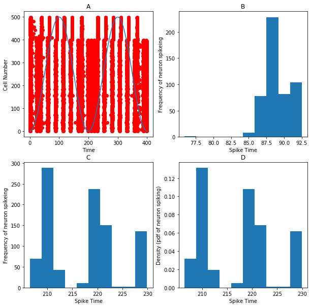

```python
import numpy as np
import matplotlib.pyplot as plt
#NOTE: SOME OF THIS CODE IS ADAPTED FROM CODE PROVIDED EARLIER IN THIS COURSE
np.random.seed(0)

T = 400      # total time to run
dt = 0.1   # time step
nt = int(np.round(T/dt)+1)     # number of entries in vector array (mV)
tvec = np.linspace(0,T,nt)     # time vector (ms)

#Get temperature vector:
tempVec = np.zeros(nt)
for i in range(0, tempVec.shape[0]):
    #start at a temperature trough, two temperature cycles across all T
    tempVec[i] = -np.cos(4*np.pi*tvec[i]/T)

N = 500 #number of neurons in our network
vecOfNeurons = np.zeros((N, 2)) #stores the activation of neuron j in column 1 and the type in column 2
vecOfNeurons[0:int(np.floor(.8*N)), 1] = 1 #1 for excitatory, -1 for inhibitory
vecOfNeurons[int(np.floor(.8*N)):N, 1] = -1
Ne = int(np.floor(.8*N)) #number of excitatory neurons in the network
Ni = N - Ne #number of inhibitory neurons in the network

#Randomly initialize each neuron:
for i in range(0,N):
    num = np.random.uniform(0,2*np.pi/3)
    vecOfNeurons[i,0] = num

#Contruct a matrix of the connections between neurons
#start with the connections between the excitatory neurons
#(wij such that 0<=i<=np.floor(.8*N), and 0<=j<=np.floor(.8*N))
W = np.zeros((N,N))

#keep track of coordinates to adjust based on temperature
rows = []
cols = []

#EE connections:
gEE = 0 #Scales the conductivity
pEE = 0 #probability that a given E neuron is connected to another E neuron
for i in range(0, int(np.floor(.8*N))):
    for j in range(0, int(np.floor(.8*N))):
        num = np.random.uniform(0,1)
        #Make a connection with probability pEE
        if num < pEE:
            #rows.append(i)
            #cols.append(j)
            W[i,j] = gEE/(Ne*pEE)

#EI connections:
gEI = .25 #Scales the conductivity
pEI = .5 #probability that a given E neuron is connected to another I neuron
for i in range(0,int(np.floor(.8*N))):
    for j in range(int(np.floor(.8*N)), N):
        num = np.random.uniform(0,1)
        #Make a connection with probability pEE
        if num < pEI:
            rows.append(i)
            cols.append(j)
            W[i,j] = gEI/(Ne*pEI)

#IE Connections
gIE = .25 #Scales the conductivity
pIE = .5 #probability that a given I neuron is connected to another E neuron
for i in range(int(np.floor(.8*N)),N):
    for j in range(0, int(np.floor(.8*N))):
        num = np.random.uniform(0,1)
        #Make a connection with probability pEE
        if num < pIE:
            W[i,j] = gIE/(Ni*pIE)

#II connections
gII = 0 #Scales the conductivity
pII = 0 #probability that a given I neuron is connected to another I neuron
for i in range(int(np.floor(.8*N)), N):
    for j in range(int(np.floor(.8*N)), N):
        num = np.random.uniform(0,1)
        #Make a connection with probability pEE
        if num < pII:
            W[i,j] = gII/(Ni*pII)

#Simulate the differential equations using forward euler:
S = np.zeros((N,N)) #Gating variable

#Initializing all the constants
IE = .1 #external forcing on the E neurons
II = 0 #external forcing on the I neurons
I = 0 #temp to be used in the loops
l=np.ones(N) #used for finding spike times (every time theta = (2l-1)pi and derivative is > 0, for each neuron)
tauE = 2 #time constant for the excitatory population
tauI = 10 #time constant for the inhibitory population
tauR = .1 #time constant for S
nu = 5 #parameter that appears in S
tau = 0 #Initializeing a temp tau for updating S

#Keep track of which neuron spiked and spike times:
neuronSpiked = []
spikeTime = []

#Step through time:
for j in np.arange(nt-1):
    #change neuron conductance based on position in temperature cycle, weaken both:
    for i in range(0, len(rows)):
        W[rows[i],cols[i]] = (tempVec[j]+1.05)*gEI/(2*Ne*pEI)
    #Step through each neuron
    for i in range(0, N):
        #Choose external forcing depending on what neuron we are updating
        if vecOfNeurons[i,1] == 1:
            I = IE
        else:
            I = II
        deriv = (1-np.cos(vecOfNeurons[i,0]) + (I +
            np.sum(np.multiply(np.multiply(vecOfNeurons[:,1], W[:,i]), S[:,i])))* (1+np.cos(vecOfNeurons[i,0])))
        vecOfNeurons[i,0] = vecOfNeurons[i,0] + dt* deriv
        if vecOfNeurons[i,0] >= (2*l[i]-1)*np.pi and deriv > 0:
            neuronSpiked.append(i)
            spikeTime.append(tvec[j+1])
            l[i]+=1
    #Update our gating variables:
    for i in range(0,N):
        for k in range(0,N):
            #choose time constant in the formula
            if vecOfNeurons[i,1] == 1:
                tau = tauE
            else:
                tau = tauI
            deriv = -1*S[i,k]/tau+np.exp(-nu*(1+np.cos(vecOfNeurons[i,0])))*(1-S[i,k])/tauR
            S[i,k] = S[i,k]+dt*deriv

fig, axs = plt.subplots(2, 2, figsize=(10, 10))
plt.subplot(221)
plt.title("A")
plt.xlabel("Time")
plt.ylabel("Cell Number")
plt.scatter(spikeTime, neuronSpiked, color = "red")
plt.plot(tvec, N/2*(tempVec+1))

synHist = []
for i in range(0, len(spikeTime)):
    if(spikeTime[i]>75 and spikeTime[i]<100):
        synHist.append(spikeTime[i])

aSynHist = []
for i in range(0, len(spikeTime)):
    if(spikeTime[i]>205 and spikeTime[i]<230):
        aSynHist.append(spikeTime[i])
plt.subplot(222)
plt.title("B")
plt.xlabel("Spike Time")
plt.ylabel("Frequency of neuron spikeing")
plt.hist(synHist)
plt.subplot(223)
plt.title("C")
plt.xlabel("Spike Time")
plt.ylabel("Frequency of neuron spikeing")
plt.hist(aSynHist)
plt.subplot(224)
plt.title("D")
plt.xlabel("Spike Time")
plt.ylabel("Density (pdf of neuron spiking)")
plt.hist(aSynHist, density = True)
plt.show()
```

Subplot A shows each neuron in the network on the y axis, and the time that said neuron spiked on the x-axis. Like the previous section, the top 20% of the neurons are I-cells and the rest are E-cells (cells numbered 400-500 are the I-cells). The curve in the background is body temperature's scaling to the conductance of the outgoing E cell signals (rescaled so it is visible, its actual domain is from 0 to 2). By inspection one can see synchronized spiking occurs only after body temperature reaches a certain level, and asynchronized spiking only occurs when body temperature is around a minima.

Subplot B gives a histogram of spikes that occur during a time window of 25 around synchronized spiking (we do not specify the time units). Comparing this to subplot C (a histogram of spikes that occur during a time window of 25 time units while the system is not synchronized) we see that many more spikes occur when the network is not synchronized as compared to when it is synchronized. This is because at a temperature trough we are violating condition 2 of the PING mechanism, and when this condition is violated we showed that even though the spikes of the E-cells look synchronized they are able to spike many more times between I-cell pulses. This explains why we see 3 different peaks in subplot C, because the E-cells are spiking 3 times in this time interval.

Subplot D shows a density histogram of the asynchronized cells. This clearly would not be fit well by the distribution that we derived earlier as we would expect (it is not unimodal). However, if we make the interval of time that we look at too small we can see that the distribution would become unimodal again, and it would probably be fit fairly well by our predicted distribution (at least at some time values). This means that we need to make the window of time that we count spikes large enough in order to distinguish between synchronized and asynchronized spiking (because the interval will need to be large enough to capture multiple spikes in it).

For all of the reasons stated above we will look at intervals of size 50 (which is certainly big enough to tell when synchronized or unsynchronized behavior is happening) and count the number of spikes that happen within that interval. We say that the network is desynchronized if more than a certain threshold of neurons spike in the time interval of 50, and we will say that the desynchronized spiking began at the start of the interval (this may bias our prediction for synchronized behavior to the left, but we are more interested in the length of sleep episodes which this bias will not affect). We then continue to slide the interval along the time-axis, and as soon as fewer neurons than threshold are spiking within the time interval we say that the desynchronized behavior stopped at the lowest time value of the interval.

Below we simulate this for two neural networks each with different frequencies in the oscillations of their outgoing E-cell connections, and we give how long each sleep episode is for each set of neural nets:

```python
import numpy as np
import matplotlib.pyplot as plt
#NOTE: SOME OF THIS CODE IS ADAPTED FROM CODE PROVIDED EARLIER IN THIS COURSE
np.random.seed(0)

T = 400      # total time to run
dt = 0.1   # time step
nt = int(np.round(T/dt)+1)     # number of entries in vector array (mV)
tvec = np.linspace(0,T,nt)     # time vector (ms)

N = 50 #number of neurons in our network
vecOfNeurons = np.zeros((N, 2)) #stores the activation of neuron j in column 1 and the type in column 2
#1 for excitatory in NN 1 and 2 for E in NN 2, -1 for inhibitory in NN 1 and -2 for I in NN 2
vecOfNeurons[0:int(np.floor(.4*N)), 1] = 1
vecOfNeurons[int(np.floor(.4*N)):int(np.floor(.8*N)), 1] = 2
vecOfNeurons[int(np.floor(.8*N)):int(np.floor(.9*N)), 1] = -1
vecOfNeurons[int(np.floor(.9*N)):N, 1] = -2
Ne = int(np.floor(.8*N)) #number of excitatory neurons in the network
Ni = (N - Ne) #number of inhibitory neurons in the network

#Randomly initialize each neuron:
for i in range(0,N):
    num = np.random.uniform(0,2*np.pi/3)
    vecOfNeurons[i,0] = num

#Contruct a matrix of the connections between neurons
#start with the connections between the excitatory neurons
#(wij such that 0<=i<=np.floor(.8*N), and 0<=j<=np.floor(.8*N))
W = np.zeros((N,N))

#keep track of coordinates to adjust based on temperature
rows1 = []
cols1 = []
rows2 = []
cols2 = []

#initialize the constants for 2 neural networks:
#Parameters for neural net to connected to itself:
gIE1 = .25 #Scales the conductivity
pIE1 = .5 #probability that a given I neuron is connected to another E neuron
gEI1 = .25
pEI1 = .5
gEE1 = 0
pEE1 = 0
gII1 = 0
pII1 = 0

#parameters for neural net 2 connected to itself:
gIE2 = .25 #Scales the conductivity
pIE2 = .5 #probability that a given I neuron is connected to another E neuron
gEI2 = .25
pEI2 = .5
gEE2 = 0
pEE2 = 0
gII2 = 0
pII2 = 0

#parameters for neural net 1's connections to neural net 2:
gI1E2 = .25 #Scales the conductivity
pI1E2 = .5 #probability that a given I neuron is connected to another E neuron
gE1I2 = .25
pE1I2 = .5
gE1E2 = 0
pE1E2 = 0
gI1I2 = 0
pI1I2 = 0

#parameters for neural net 2's connections to neural net 1:
gI2E1 = .25 #Scales the conductivity
pI2E1 = .5 #probability that a given I neuron is connected to another E neuron
gE2I1 = .25
pE2I1 = .5
gE2E1 = 0
pE2E1 = 0
gI2I1 = 0
pI2I1 = 0

for i in range(0, N):
    for j in range(0, N):
        num = np.random.uniform(0,1)
        #check what connection we are making
        if vecOfNeurons[i,1] == 1 and vecOfNeurons[j,1] == 1:
            #make connection using probabilities we already defined
            if num < pEE1:
                W[i,j] = gEE1/(Ne*pEE1)
        if vecOfNeurons[i,1] == 1 and vecOfNeurons[j,1] == -1:
            if num < pEI1:
                rows1.append(i)
                cols1.append(j)
                W[i,j] = gEI1/(Ne*pEI1)
        if vecOfNeurons[i,1] == -1 and vecOfNeurons[j,1] == 1:
            if num < pIE1:
                W[i,j] = gIE1/(Ni*pIE1)
        if vecOfNeurons[i,1] == -1 and vecOfNeurons[j,1] == -1:
            if num < pII1:
                W[i,j] = gII1/(Ni*pII1)


        if vecOfNeurons[i,1] == 2 and vecOfNeurons[j,1] == 2:
            #make connection using probabilities we already defined
            if num < pEE2:
                W[i,j] = gEE2/(Ne*pEE2)
        if vecOfNeurons[i,1] == 2 and vecOfNeurons[j,1] == -2:
            if num < pEI2:
                rows2.append(i)
                cols2.append(j)
                W[i,j] = gEI2/(Ne*pEI2)
        if vecOfNeurons[i,1] == -2 and vecOfNeurons[j,1] == 2:
            if num < pIE2:
                W[i,j] = gIE2/(Ni*pIE2)
        if vecOfNeurons[i,1] == -2 and vecOfNeurons[j,1] == -2:
            if num < pII2:
                W[i,j] = gII2/(Ni*pII2)


        if vecOfNeurons[i,1] == 1 and vecOfNeurons[j,1] == 2:
            #make connection using probabilities we already defined
            if num < pE1E2:
                W[i,j] = gE1E2/(Ne*pE1E2)
        if vecOfNeurons[i,1] == 1 and vecOfNeurons[j,1] == -2:
            if num < pE1I2:
                rows1.append(i)
                cols1.append(j)
                W[i,j] = gE1I2/(Ne*pE1I2)
        if vecOfNeurons[i,1] == -1 and vecOfNeurons[j,1] == 2:
            if num < pI1E2:
                W[i,j] = gI1E2/(Ni*pI1E2)
        if vecOfNeurons[i,1] == -1 and vecOfNeurons[j,1] == -2:
            if num < pI1I2:
                W[i,j] = gI1I2/(Ni*pI1I2)


        if vecOfNeurons[i,1] == 2 and vecOfNeurons[j,1] == 1:
            #make connection using probabilities we already defined
            if num < pE2E1:
                W[i,j] = gE2E1/(Ne*pE2E1)
        if vecOfNeurons[i,1] == 2 and vecOfNeurons[j,1] == -1:
            if num < pE2I1:
                rows2.append(i)
                cols2.append(j)
                W[i,j] = gE2I1/(Ne*pE2I1)
        if vecOfNeurons[i,1] == -2 and vecOfNeurons[j,1] == 1:
            if num < pI2E1:
                W[i,j] = gI2E1/(Ni*pI2E1)
        if vecOfNeurons[i,1] == -2 and vecOfNeurons[j,1] == -1:
            if num < pI2I1:
                W[i,j] = gI2I1/(Ni*pI2I1)



#Simulate the differential equations using forward euler:
S = np.zeros((N,N)) #Gating variable

#Initializing all the constants
IE1 = .1 #external forcing on the E1 neurons
II1 = 0 #external forcing on the I1 neurons
IE2 = .1 #external forcing on the E2 neurons
II2 = 0 #external forcing on the I2 neurons
I = 0 #temp to be used in the loops
l=np.ones(N) #used for finding spike times (every time theta = (2l-1)pi and derivative is > 0, for each neuron)
tauE1 = 2 #time constant for the excitatory population for NN 1
tauI1 = 10 #time constant for the inhibitory population for NN 1
tauE2 = 2 #time constant for the excitatory population for NN 2
tauI2 = 10 #time constant for the inhibitory population for NN 2
tauR = .1 #time constant for S
nu = 5 #parameter that appears in S
tau = 0 #Initializeing a temp tau for updating S

#Keep track of which neuron spiked and spike times:
neuronSpiked = []
spikeTime = []


#Get temperature vectors (in phase this time):
tempVec1 = np.zeros(nt)
for i in range(0, tempVec1.shape[0]):
    #start at a temperature trough, two temperature cycles across all T
    tempVec1[i] = -np.cos(4*np.pi*tvec[i]/T)
```

```python
tempVec2 = np.zeros(nt)
for i in range(0, tempVec2.shape[0]):
    #start at a temperature trough, two temperature cycles across all T
    tempVec2[i] = -np.cos(4*np.pi*tvec[i]/T)

#Step through time:
for j in np.arange(nt-1):
    #change neuron conductance based on position in temperature cycle:
    for i in range(0, len(rows1)):
        W[rows1[i],cols1[i]] = (tempVec1[j]+1.05)*gEI1/(2*Ne*pEI1)
    for i in range(0, len(rows2)):
        W[rows2[i],cols2[i]] = (tempVec2[j]+1.05)*gEI2/(2*Ne*pEI2)
    #Step through each neuron
    for i in range(0, N):
        #Choose external forcing depending on what neuron we are updating
        if vecOfNeurons[i,1] == 1:
            I = IE1
        elif vecOfNeurons[i,1] == -1:
            I = II1
        elif vecOfNeurons[i,1] == 2:
            I = IE2
        else:
            I = II2
        deriv = (1-np.cos(vecOfNeurons[i,0]) + (I +
            np.sum(np.multiply(np.multiply(vecOfNeurons[:,1], W[:,i]), S[:,i])))* (1+np.cos(vecOfNeurons[i,0])))
        vecOfNeurons[i,0] = vecOfNeurons[i,0] + dt* deriv
        if vecOfNeurons[i,0] >= (2*l[i]-1)*np.pi and deriv > 0:
            neuronSpiked.append(i)
            spikeTime.append(tvec[j+1])
            l[i]+=1
    #Update our gating variables:
    for i in range(0,N):
        for k in range(0,N):
            #choose time constant in the formula
            if vecOfNeurons[i,1] == 1:
                tau = tauE1
            elif vecOfNeurons[i, 1] == -1:
                tau = tauI1
            elif vecOfNeurons[i,1] == 2:
                tau = tauE2
            else:
                tau = tauI2
            deriv = -1*S[i,k]/tau+np.exp(-nu*(1+np.cos(vecOfNeurons[i,0])))*(1-S[i,k])/tauR
            S[i,k] = S[i,k]+dt*deriv
fig, axs = plt.subplots(2, 2, figsize=(20, 20))
plt.subplot(221)
plt.title("A")
plt.xlabel("Time")
plt.ylabel("Cell Number")
plt.scatter(spikeTime, neuronSpiked, color = "red")
plt.plot(tvec, N/2*(tempVec1+1), color = "blue")
plt.plot(tvec, N/2*(tempVec2+1), color = "green")

intervalLen = 50
sleepFlag = 0
numSleepEpisodes = 0
for i in range(50, T-100):
    t1 = i
    t2 = i + intervalLen
    numSpiked = 0
    for j in range(0, len(spikeTime)):
        if spikeTime[j] >= t1 and spikeTime[j] <= t2:
            numSpiked += 1
    if numSpiked > N*2.5 and sleepFlag == 0:
        numSleepEpisodes += 1
        print("Sleep onset for sleep episode {} subplot A:".format(numSleepEpisodes))
        print(i)
        sleepOnset = i
        sleepFlag = 1
    if numSpiked < N*3/2 and sleepFlag == 1:
        print("Sleep ending for subplot A:")
        print(i)
        print("Sleep duration for {} sleep cycle:".format(numSleepEpisodes))
        print(i-sleepOnset)
        sleepFlag = 0
if numSleepEpisodes == 0:
    print("No sleep predicted in subplot A")


S = np.zeros((N,N)) #Gating variable
l=np.ones(N) #used for finding spike times (every time theta = (2l-1)pi and derivative is > 0, for each neuron)
#Keep track of which neuron spiked and spike times:
neuronSpiked = []
spikeTime = []
#Get temperature vectors (in phase this time):
tempVec1 = np.zeros(nt)
for i in range(0, tempVec1.shape[0]):
    #start at a temperature trough, two temperature cycles across all T
    tempVec1[i] = -np.cos(4*np.pi*tvec[i]/T)

tempVec2 = np.zeros(nt)
for i in range(0, tempVec2.shape[0]):
    #start at a temperature trough, two temperature cycles across all T
    tempVec2[i] = -np.cos(2*np.pi*tvec[i]/T)

#Step through time:
for j in np.arange(nt-1):
    #change neuron conductance based on position in temperature cycle:
    for i in range(0, len(rows1)):
        W[rows1[i],cols1[i]] = (tempVec1[j]+1.05)*gEI1/(2*Ne*pEI1)
    for i in range(0, len(rows2)):
        W[rows2[i],cols2[i]] = (tempVec2[j]+1.05)*gEI2/(2*Ne*pEI2)
    #Step through each neuron
    for i in range(0, N):
        #Choose external forcing depending on what neuron we are updating
        if vecOfNeurons[i,1] == 1:
            I = IE1
        elif vecOfNeurons[i,1] == -1:
            I = II1
        elif vecOfNeurons[i,1] == 2:
            I = IE2
        else:
            I = II2
        deriv = (1-np.cos(vecOfNeurons[i,0]) + (I +
            np.sum(np.multiply(np.multiply(vecOfNeurons[:,1], W[:,i]), S[:,i])))* (1+np.cos(vecOfNeurons[i,0])))
        vecOfNeurons[i,0] = vecOfNeurons[i,0] + dt* deriv
        if vecOfNeurons[i,0] >= (2*l[i]-1)*np.pi and deriv > 0:
            neuronSpiked.append(i)
            spikeTime.append(tvec[j+1])
            l[i]+=1
    #Update our gating variables:
    for i in range(0,N):
        for k in range(0,N):
            #choose time constant in the formula
            if vecOfNeurons[i,1] == 1:
                tau = tauE1
            elif vecOfNeurons[i, 1] == -1:
                tau = tauI1
            elif vecOfNeurons[i,1] == 2:
                tau = tauE2
            else:
                tau = tauI2
            deriv = -1*S[i,k]/tau+np.exp(-nu*(1+np.cos(vecOfNeurons[i,0])))*(1-S[i,k])/tauR
            S[i,k] = S[i,k]+dt*deriv
plt.subplot(222)
plt.title("B")
plt.xlabel("Time")
plt.ylabel("Cell Number")
plt.scatter(spikeTime, neuronSpiked, color = "red")
plt.plot(tvec, N/2*(tempVec1+1), color = "blue")
plt.plot(tvec, N/2*(tempVec2+1), color = "green")

intervalLen = 50
sleepFlag = 0
numSleepEpisodes = 0
for i in range(50, T-100):
    t1 = i
    t2 = i + intervalLen
    numSpiked = 0
    for j in range(0, len(spikeTime)):
        if spikeTime[j] >= t1 and spikeTime[j] <= t2:
            numSpiked += 1
    if numSpiked > N*2.5 and sleepFlag == 0:
        numSleepEpisodes += 1
        print("Sleep onset for sleep episode {} subplot B:".format(numSleepEpisodes))
        print(i)
        sleepOnset = i
        sleepFlag = 1
    if numSpiked < N*3/2 and sleepFlag == 1:
        print("Sleep ending for subplot B:")
        print(i)
        print("Sleep duration for {} sleep cycle:".format(numSleepEpisodes))
        print(i-sleepOnset)
        sleepFlag = 0
if numSleepEpisodes == 0:
    print("No sleep predicted in subplot B")
```

```python
S = np.zeros((N,N)) #Gating variable
l=np.ones(N) #used for finding spike times (every time theta = (2l-1)pi and derivative is > 0, for each neuron)
#Keep track of which neuron spiked and spike times:
neuronSpiked = []
spikeTime = []
#Get temperature vectors (in phase this time):
tempVec1 = np.zeros(nt)
for i in range(0, tempVec1.shape[0]):
    #start at a temperature trough, two temperature cycles across all T
    tempVec1[i] = -np.cos(4*np.pi*tvec[i]/T)

tempVec2 = np.zeros(nt)
for i in range(0, tempVec2.shape[0]):
    #start at a temperature trough, two temperature cycles across all T
    tempVec2[i] = np.cos(2*np.pi*tvec[i]/T)

#Step through time:
for j in np.arange(nt-1):
    #change neuron conductance based on position in temperature cycle:
    for i in range(0, len(rows1)):
        W[rows1[i],cols1[i]] = (tempVec1[j]+1.05)*gEI1/(2*Ne*pEI1)
    for i in range(0, len(rows2)):
        W[rows2[i],cols2[i]] = (tempVec2[j]+1.05)*gEI2/(2*Ne*pEI2)
    #Step through each neuron
    for i in range(0, N):
        #Choose external forcing depending on what neuron we are updating
        if vecOfNeurons[i,1] == 1:
            I = IE1
        elif vecOfNeurons[i,1] == -1:
            I = II1
        elif vecOfNeurons[i,1] == 2:
            I = IE2
        else:
            I = II2
        deriv = (1-np.cos(vecOfNeurons[i,0]) + (I +
            np.sum(np.multiply(np.multiply(vecOfNeurons[:,1], W[:,i]), S[:,i])))* (1+np.cos(vecOfNeurons[i,0])))
        vecOfNeurons[i,0] = vecOfNeurons[i,0] + dt* deriv
        if vecOfNeurons[i,0] >= (2*l[i]-1)*np.pi and deriv > 0:
            neuronSpiked.append(i)
            spikeTime.append(tvec[j+1])
            l[i]+=1
    #Update our gating variables:
    for i in range(0,N):
        for k in range(0,N):
            #choose time constant in the formula
            if vecOfNeurons[i,1] == 1:
                tau = tauE1
            elif vecOfNeurons[i, 1] == -1:
                tau = tauI1
            elif vecOfNeurons[i,1] == 2:
                tau = tauE2
            else:
                tau = tauI2
            deriv = -1*S[i,k]/tau+np.exp(-nu*(1+np.cos(vecOfNeurons[i,0])))*(1-S[i,k])/tauR
            S[i,k] = S[i,k]+dt*deriv
plt.subplot(223)
plt.title("C")
plt.xlabel("Time")
plt.ylabel("Cell Number")
plt.scatter(spikeTime, neuronSpiked, color = "red")
plt.plot(tvec, N/2*(tempVec1+1), color = "blue")
plt.plot(tvec, N/2*(tempVec2+1), color = "green")

intervalLen = 50
sleepFlag = 0
numSleepEpisodes = 0
for i in range(50, T-100):
    t1 = i
    t2 = i + intervalLen
    numSpiked = 0
    for j in range(0, len(spikeTime)):
        if spikeTime[j] >= t1 and spikeTime[j] <= t2:
            numSpiked += 1
    if numSpiked > N*2.5 and sleepFlag == 0:
        numSleepEpisodes += 1
        print("Sleep onset for sleep episode {} subplot C:".format(numSleepEpisodes))
        print(i)
        sleepOnset = i
        sleepFlag = 1
    if numSpiked < N*3/2 and sleepFlag == 1:
        print("Sleep ending for subplot C:")
        print(i)
        print("Sleep duration for {} sleep cycle:".format(numSleepEpisodes))
        print(i-sleepOnset)
        sleepFlag = 0
if numSleepEpisodes == 0:
    print("No sleep predicted in subplot C")



S = np.zeros((N,N)) #Gating variable
l=np.ones(N) #used for finding spike times (every time theta = (2l-1)pi and derivative is > 0, for each neuron)
#Keep track of which neuron spiked and spike times:
neuronSpiked = []
spikeTime = []
#Get temperature vectors (in phase this time):
tempVec1 = np.zeros(nt)
for i in range(0, tempVec1.shape[0]):
    #start at a temperature trough, two temperature cycles across all T
    tempVec1[i] = -np.cos(16*np.pi*tvec[i]/T)

tempVec2 = np.zeros(nt)
for i in range(0, tempVec2.shape[0]):
    #start at a temperature trough, two temperature cycles across all T
    tempVec2[i] = -np.cos(4*np.pi*tvec[i]/T)

#Step through time:
for j in np.arange(nt-1):
    #change neuron conductance based on position in temperature cycle:
    for i in range(0, len(rows1)):
        W[rows1[i],cols1[i]] = (tempVec1[j]+1.05)*gEI1/(2*Ne*pEI1)
    for i in range(0, len(rows2)):
        W[rows2[i],cols2[i]] = (tempVec2[j]+1.05)*gEI2/(2*Ne*pEI2)
    #Step through each neuron
    for i in range(0, N):
        #Choose external forcing depending on what neuron we are updating
        if vecOfNeurons[i,1] == 1:
            I = IE1
        elif vecOfNeurons[i,1] == -1:
            I = II1
        elif vecOfNeurons[i,1] == 2:
            I = IE2
        else:
            I = II2
        deriv = (1-np.cos(vecOfNeurons[i,0]) + (I +
            np.sum(np.multiply(np.multiply(vecOfNeurons[:,1], W[:,i]), S[:,i])))* (1+np.cos(vecOfNeurons[i,0])))
        vecOfNeurons[i,0] = vecOfNeurons[i,0] + dt* deriv
        if vecOfNeurons[i,0] >= (2*l[i]-1)*np.pi and deriv > 0:
            neuronSpiked.append(i)
            spikeTime.append(tvec[j+1])
            l[i]+=1
    #Update our gating variables:
    for i in range(0,N):
        for k in range(0,N):
            #choose time constant in the formula
            if vecOfNeurons[i,1] == 1:
                tau = tauE1
            elif vecOfNeurons[i, 1] == -1:
                tau = tauI1
            elif vecOfNeurons[i,1] == 2:
                tau = tauE2
            else:
                tau = tauI2
            deriv = -1*S[i,k]/tau+np.exp(-nu*(1+np.cos(vecOfNeurons[i,0])))*(1-S[i,k])/tauR
            S[i,k] = S[i,k]+dt*deriv
plt.subplot(224)
plt.title("D")
plt.xlabel("Time")
plt.ylabel("Cell Number")
plt.scatter(spikeTime, neuronSpiked, color = "red")
plt.plot(tvec, N/2*(tempVec1+1), color = "green")
plt.plot(tvec, N/2*(tempVec2+1), color = "blue")

intervalLen = 50
sleepFlag = 0
numSleepEpisodes = 0
for i in range(50, T-100):
    t1 = i
    t2 = i + intervalLen
    numSpiked = 0
    for j in range(0, len(spikeTime)):
        if spikeTime[j] >= t1 and spikeTime[j] <= t2:
            numSpiked += 1
    if numSpiked > N*2.5 and sleepFlag == 0:
        numSleepEpisodes += 1
        print("Sleep onset for sleep episode {} subplot D:".format(numSleepEpisodes))
        print(i)
        sleepOnset = i
        sleepFlag = 1
    if numSpiked < N*3/2 and sleepFlag == 1:
        print("Sleep ending for subplot D:")
        print(i)
        print("Sleep duration for {} sleep cycle:".format(numSleepEpisodes))
        print(i-sleepOnset)
        sleepFlag = 0
if numSleepEpisodes == 0:
    print("No sleep predicted in subplot D")
```

```
Sleep onset for sleep episode 1 subplot A:
144
Sleep ending for subplot A:
235
Sleep duration for 1 sleep cycle:
91
No sleep predicted in subplot B
Sleep onset for sleep episode 1 subplot C:
144
Sleep ending for subplot C:
246
Sleep duration for 1 sleep cycle:
102
Sleep onset for sleep episode 1 subplot D:
161
Sleep ending for subplot D:
219
Sleep duration for 1 sleep cycle:
58
```

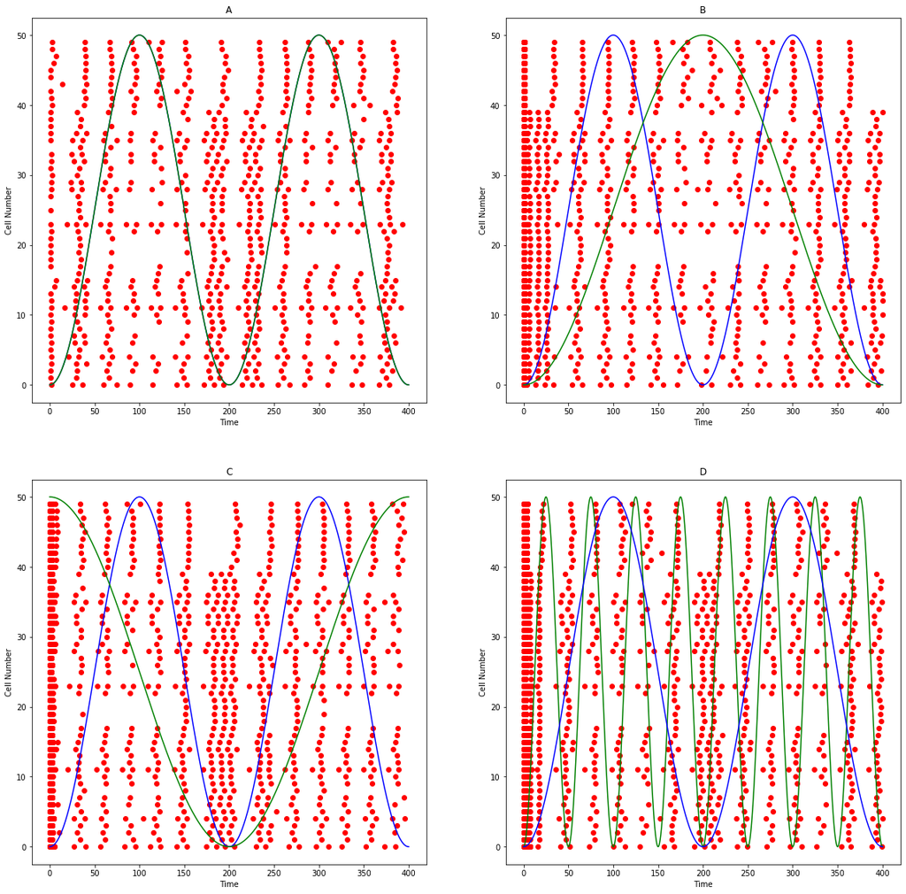

```python
plt.show()
```

As before, the rescaled curves in the background represent the frequency of each neural network (how much we are scaling the values of the outgoing E-cell conductance), and the top 20% of neurons are I-cells and the rest are E-cells (so 40-50 are I-cells), also note that the first half of each cell population belongs to one neural network and the top half belongs to another neural net (so 0-20 are E-cells of neural network 1 and 40-45 are I-cells of neural net 1). Please note that we are ignoring the desynchronized behavior at time 0 since this will always be present because of the way we initialized the neurons.

Subplot C shows that by changing one neural network so that it has a lower frequency we will get a longer sleep cycle. This is because, in this case, it takes longer for one of the network's mean synaptic conductance to increase to the point where synchronized behavior is possible, so the expected input stays below the threshold required for both networks to be synchronized for longer. The duration of sleep expected in this case is 102.

Subplot D shows that we can shorten a sleep episode by increasing the frequency of one of the neural networks. This is because the average synaptic conductance will increase faster in this case, so synchronized behavior is possible sooner. The sleep duration expected in this case is 58.

# Discussion

In [1] a neural model was proposed that was capable of synchronized behavior in conditions when the connections between neurons were sparse. To me, the most natural neurobiological interpretation of such a network would be one that involves neurons that are a part of many different systems (like motor neurons, higher level reasoning neurons, etc) that also have a secondary function (circadian rhythm, etc). Take circadian rhythm for example (as we discuss this throughout the paper). One might expect that many different types of neurons are involved in sleep/wake cycles (motor neurons that make eyes 'droop' when you are tired, sensory neurons that detect when it is dark, etc), but sleep may not be their only function. Many of them might control functions that are essential to daily life, and they would most likely be densely connected to other neurons involved in their primary function. However, if you were to just extract all of the neurons involved in circadian rhythm the network would likely be rather sparse since circadian cycles would not be their primary function, but since synchronized behavior is still possible in such a network the brain has a way of differentiating when the network is simply performing their disparate primary functions vs when they are performing their secondary function.

One might reasonably ask if this means that all areas of the brain that perform any related function will attain synchronized activity. This need not be the case because the analysis provided by [1]. It was found that the variance in the amount of input in each cell determined whether or not the network could achieve approximate synchronicity, and since the variance in the number of inputs is determined by how sparse the network is (with more densely connected networks having less variance in the inputs to each neuron) we would expect that there is some critical number of expected connections that would be required to attain synchronized behavior. This means that neural networks that are barely related in function would not attain synchronicity. We can also note that loosely connected neural networks would probably have relatively low synaptic connectivity with the network they are loosely connected to which would violate one if not more than one of the conditions the authors of [1] found that allow PING based synchronicity to occur.

Circadian rhythm is of particular interest to me as it is not well modeled by a single neural network that responds to just body temperature. We showed that you can get a network to respond to changes in body temperature (modeled as a simple cosine wave) with synchronized or unsynchronized activity. Since body temperature does not really deviate from its normal cycle [2] we are unable to reproduce variable sleep lengths with just one neural network. To solve this we can introduce another neural network whose frequency is different from that of the temperature affected neural network. We will interpret the frequency of the oscillations associated with this second network's outgoing E-cell signals as dependent upon external circadian stimuli. With this network interacting with the original network we can adjust the length of sleep cycles or even miss entire sleep episodes if the networks are completely out of phase. This might explain external effects on sleep such as jet lag. If the external stimuli tells us to go to sleep, but out internal body temperature network is at a temperature max this circadian network will still be synchronized (which predicts wakefulness). This means that one is unable to go to sleep if your surroundings change too suddenly despite internal signals telling you to sleep because body temperature has not yet adjusted to the change. This might also provide an explanation to why common wisdom such as going to sleep at similar times each evening to improve sleep quality. If you vary the time of sleep each evening then the temperature network might be attuned to the previous sleep cycle's timing, but by going to sleep at a different time the external stimulus network might be in a slightly different phase than the temperature, which we showed can affect sleep length.

One thing that was not accounted for in our analysis was the dependency of internally desynchronized subjects sleep episodes on body temperature. [2] states that elongated sleep episodes usually began near temperature peaks and shorter episodes began near temperature troughs in internally desynchronized subjects. This presents a problem for the two neural network model as we had always assumed that sleep cycles would begin at temperature troughs (as they do for normal subjects). A slight modification to the neural networks can fix this though. If we allow the amplitude of the temperature network's $g_{EI}$ parameter to vary in time as well we should be able to get desynchronized behavior even when the temperature network would predict synchronicity. A biological explanation of this might be that the level of expression of AMPA channels in temperature dependent neurons can be down regulated by signals from other circadian stimuli. For instance, if a subject was in complete darkness then we would expect the pineal gland to release melatonin (a peptide hormone) which could theoretically affect the expression levels of genes. With fewer AMPA channels one would expect the max conductance of that neural network's EI connections to decrease, making desynchronization possible because the temperature neural network is suddenly less important for the synchronization state of the two neural networks than the other neural network. This might also explain why desynchronization takes a while to effect patients deprived of external circadian stimuli because adjustments to expression levels of AMPA channels would most likely take a much longer to have a noticeable effect (since prior AMPA channels would need to be degraded by the cell in order for the effect to be noticeable). Please note that I am not asserting that this specific mechanism is feasible, I am just asserting that there are examples where circadian stimuli might affect the expression level of a gene, but melatonin may not be a feasible answer. It might also be the case that varying a different quantity in time in the second neural network might be able to reproduce this result.

It is important to note that there is no reason why the time varying quantity in the second neural net (the one that accounts for external stimuli) should be the conductance of the outgoing E-cell connections. We chose to keep the time varying quantity consistent across both networks so the effect was more predictable, but an interesting extension might be to vary other quantities in the second neural net and see if results from internally desynchronized subjects are replicable. Another interesting extension to this project would be to allow the amplitude of the fluctuations in the outgoing E connections of the temperature based neural network to vary in time on a proper physiological time scale to see if elongated sleep episodes are possible at temperature maxes after a sufficient time being deprived of external circadian stimulus.

Works cited:  
[1] Börgers, C., & Kopell, N. (2003). Synchronization in Networks of Excitatory and Inhibitory Neurons with Sparse, Random Connectivity. Neural Computation, 15(3), 509–538. doi: 10.1162/089976603321192059  
[2] Strogatz, S. H. (1987). Human sleep and circadian rhythms: a simple model based on two coupled oscillators. Journal of Mathematical Biology, 25(3), 327–347. doi: 10.1007/bf00276440  
[3] Kufel, D. S., & Wojcik, G. M. (2018, June). Analytical modelling of temperature effects on an AMPA-type synapse. Retrieved from https://www.ncbi.nlm.nih.gov/pubmed/29752691  
[4] Taylor expansions for the moments of functions of random variables. (2019, December 3). Retrieved from https://en.wikipedia.org/wiki/Taylor_expansions_for_the_moments_of_functions_of_random_variables